# Многомерная модель VAR

© Alexander Doynikov,dep.Statisical Analysis, CS, MSU

Septemper 23, 2018

На практике нас чаще всего интересуют процессы многомерные, поведение которых в некотором смысле связано между собой. Итак пусть теперь $x_{t}$-векторный случайный процесс размерности $(n×1)$. Векторным процессом авторегрессии порядка $p$ (сокращенно VAR(p) ) будем называть процесс вида
$$x_{t}=с+\Phi_{1}x_{t-1}+...+\Phi_{p}x_{t-p}+\epsilon_{t}$$

где c- вектор (n×1) констант, $\Phi_{i}; i=1,...p$- матрицы размера (n×n) и $\epsilon_{t}$-многомерный (n×1)процесс белого шума

$$E\epsilon_{t}=0$$
$$E\epsilon_{t}\epsilon_{s}=\Omega$$
при $t=s$; 0 иначе, где $\Omega$- симметричная положительно определенная (n×n) матрица ковариаций.

Выпишем соотношение, например, для первого из компонент вектора $x_{t}$
$$x_{1,t} = c_1+\Phi_{1,1}^{(1)}x_{1,t-1}+\Phi_{1,2}^{(1)}x_{2,t-1}...+\Phi_{1,n}^{(1)}x_{n,t-1}+ \Phi_{1,1}^{(2)} x_{1,t-2}+\Phi_{1,2}^{(2)} x_{2,t-2}+...+\Phi_{1,n}^{(2)} x_{n,t-2} +...+$$
$$\Phi_{1,1}^{(p)} x_{1,t-p}+\Phi_{1,2}^{(p)}x_{2,t-p}...+\Phi_{1,n}^{(p)}x_{n,t-p}+\epsilon_{t,1}$$

Таким образом каждая из компонент процесса представляет собой одновременно как линейную регрессионную модель от других компонент процесса, но взятых с задержкой по времени и авторегрессионную модель от самой себя.

Используя векторный оператор задержки $Bx_{t}=x_{t-1}$ модель может быть записана в форме

$$[I_{n}-\Phi_1B-...-\Phi_{p}B^{p}]x_{t}=c+\epsilon_{t}$$

или

$$\Phi(B)x_{t}=c+\epsilon_{t}$$

где $\Phi(B)$- матрица размера (n×n) полиномов от оператора задержки, каждый элемент которой представляет собой скалярный полином от задержки

$$\Phi(B)=[\delta_{ij}-\Phi_{ij}B-...-\Phi_{ij}^{p}B^{p}]; i,j=1,...,n$$

где $\delta_{ij}=1$ при $i=j$, иначе 0

Процесс VAR(p) называют стационарным в широком смысле (или просто стационарным), если его первый и второй момент $Ex_{t}$ и $Ex_{t}x_{t-j}′$ соответсвенно не зависит от времени $t$.

Если процесс стационарен, то мы можем взять математическое ожидание от обеих частей и вычислить математическое ожидание процесса. Обозначим вектор математических ожиданий через $\mu=Ex_{t}$, тогда
$$\mu=с+\Phi₁\mu+...+\Phi_{p}\mu$$
Откуда
$$\mu=(I_{n}-\Phi_1-...-\Phi_{p})^{-1}c$$
Используя вектор математических ожиданий $\mu$, модель VAR(p) может быть эквивалентно переписана в терминах отклонений от среднего $\mu$.
$$x_{t}-\mu=\Phi_1(x_{t-1}-\mu)+...+\Phi_{p}(x_{t-p}-\mu)+\epsilon_{t}$$

Предложение. Многомерная модель VAR(p), так и одномерная модель AR(p) может быть переписана как многомерная модель VAR(1) Доказательство. Действительно, обозначим через $\xi_{t}$- многомерный размера (np×1)процесс вида
$$\begin{equation*}\xi_{t}=\left[ \begin{matrix}x_t-\mu\\ x_{t-1}-\mu\\
....\\x_{t-p}-\mu\end{matrix}\right] \end{equation*}$$
Пусть $F$ матрица размера (np×np)
$$\begin{equation*}F=\left[ \begin{matrix}\
\Phi_1&\Phi_2&\Phi_3&...&\Phi_p\\
I_n&0&0&...&0\\
0&I_n&0&...&0\\
...\\
0&0&...&I_n&0&\\
\end{matrix}\right] \end{equation*}$$
и через $ν_{t}$- (np×1)-й процесс
$$\begin{equation*}v_{t}=\left[ \begin{matrix}\epsilon_t\\0\\...\\0\end{matrix}\right] \end{equation*}$$
Тогда многомерный VAR(p) процесс может быть эквивалентно переписан, как VAR(1) процесс вида
$$\xi_{t}=F\xi_{t-1}+ν_{t}$$
Доказанный факт чаще всего используется при доказательстве различных утверждений относительно процесса VAR(p).

## 0.1 Условия стационарности процесса VAR(p)

Для процесса VAR(1) $\xi_{t}$ , введенного выше справедливо следующее выражение
$$\xi_{t+s}=ν_{t+s}+Fν_{t+s-1}+F^2ν_{t+s-2}+...+F^{s-1}ν_{t+1}+F^{s}\xi_{t}$$

Для того, чтобы процесс был стационарным влияние шума $\epsilon_{t}$ в конце концов должно исчезнуть. Оказывается, что если все собственные значения матрицы $F$ лежат внутри единичного круга, то процесс $\xi_{t}$ будет стационарным в широком смысле. Без доказательства примем на веру следующее утверждение Теорема. Все $\lambda$- собственные значения матрицы $F$, удовлетворяют уравнению
$$|I_{n}\lambda^{p}-\Phi_1\lambda^{p-1}-\Phi_2\lambda^{p-2}...-\Phi_{p}|=0$$
Следовательно, процесс VAR(p) является стационарным тогда и только тогда, когда все собственные значения матрицы F по модулю меньше единицы $|\lambda|<1$, что в свою очередь эквивалентно тому, все корни $z$ уравнения
$$|I_{n}-\Phi_1z-\Phi_2z²...-\Phi_{p}z^{p}|=0$$
лежат вне единичного круга. Доказательство этого утверждения можно найти в J.Hamilton. Time Series Analysis p.285.

## 0.2 Автоковариационная функция векторного процесса

Для стационарного векторного процесса $x_{t}$ размера (n×1) $k$-ой автоковариацией назовем матрицу (n×n)
$$\Gamma_{k}=E[(x_{t}-\mu)(x_{t-k}-\mu)′]$$
Вспомним, что для одномерных процессов автоковариационная функция является четной функцией $c_{k}=c_{-k}$ , для векторного процесса это не верно.
$$\Gamma_{k}\ne\Gamma_{-k}$$
Однако, нетрудно убедиться, что
$$\Gamma_{k}′=\Gamma_{-k}$$

Действительно. Для стационарного процесса будет справедливо
$$\Gamma_{k}=E[(x_{t+k}-\mu)(x_{(t+k)-k}-\mu)′]=E[(x_{t+k}-\mu)(x_{t}-\mu)′]$$
Транспонируем
$$\Gamma_{k}′=E[(x_{t}-\mu)'(x_{t+k}-\mu)]=\Gamma_{-k}$$
В языке R соответствующая библиотека для работы с многомерными авторегрессионными моделями называется mAr Cмоделируем VAR(2) процесс размерности 3

Сначала зададим модель вектор констант $c$ и матрицы $\Phi_1,\Phi_2$ и ковариационную матрицу $\Omega$

```r
library(mAr)
w <- c(1,4,8)
Phi1 <- c(0.1,-0.2,-0.3)
Phi1 <- rbind(Phi1,c(0.1,0.-0.2,0.3))
Phi1 <- rbind(Phi1,c(0.2,0.2,0.2))
Phi1
```

```
##      [,1] [,2] [,3]
## Phi1  0.1 -0.2 -0.3
##       0.1 -0.2  0.3
##       0.2  0.2  0.2
```

```r
Phi2 <- c(0.1,0.1,0.1)
Phi2 <- rbind(Phi2,c(0.15,0.1,0.15))
Phi2 <- rbind(Phi2,c(0.1,0.1,0.1))
Phi2
```

```
##      [,1] [,2] [,3]
## Phi2 0.10  0.1 0.10
##      0.15  0.1 0.15
##      0.10  0.1 0.10
```

```r
Phi <- cbind(Phi1,Phi2)
Phi
```

```
##      [,1] [,2] [,3] [,4] [,5] [,6]
## Phi1  0.1 -0.2 -0.3 0.10  0.1 0.10
##       0.1 -0.2  0.3 0.15  0.1 0.15
##       0.2  0.2  0.2 0.10  0.1 0.10
```

```r
Omega <- diag(4,3,3)
Omega
```

```
##      [,1] [,2] [,3]
## [1,]    4    0    0
## [2,]    0    4    0
## [3,]    0    0    4
```

Cформируем из матриц $\Phi_1,\Phi_2$ матрицу $F$ для того, чтобы проверить стационарность модели

```r
I <- diag(1,3,3)
Zero <- diag(0,3,3)
IZ <- cbind(I,Zero)
F <- rbind(Phi,IZ)
F
```

```
##      [,1] [,2] [,3] [,4] [,5] [,6]
## Phi1  0.1 -0.2 -0.3 0.10  0.1 0.10
##       0.1 -0.2  0.3 0.15  0.1 0.15
##       0.2  0.2  0.2 0.10  0.1 0.10
##       1.0  0.0  0.0 0.00  0.0 0.00
##       0.0  1.0  0.0 0.00  0.0 0.00
##       0.0  0.0  1.0 0.00  0.0 0.00
```

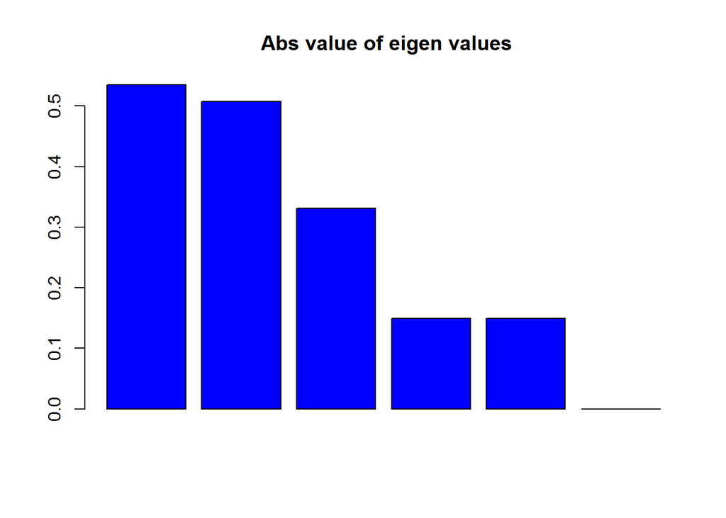

```r
eval <- eigen(F,only.values= TRUE)
modev <- Mod(eval$values)
barplot(modev,col = "blue",main = " Abs value of eigen values")
abline(h=1,col = "black")
```

Все собственные значения по модулю <1, следовательно ряд стационарен Моделируем и смотрим результат

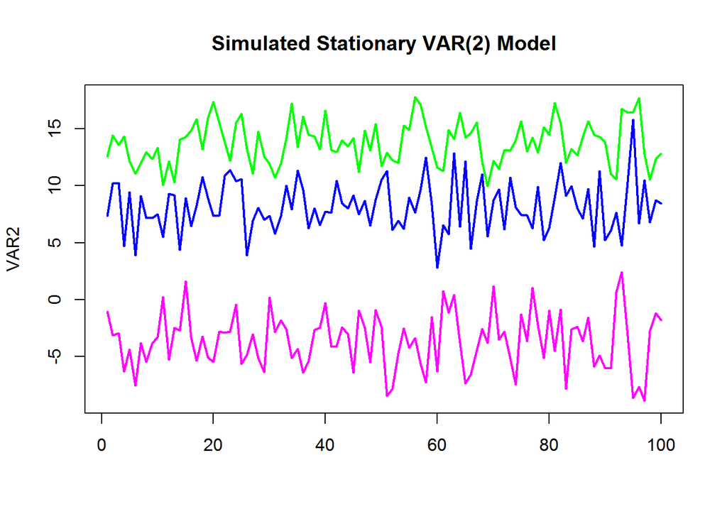

```r
VAR2 <- mAr.sim(w, Phi, Omega, 100)
matplot(VAR2,type="l",lty = 1, col=c("magenta","blue","green"),lwd=2,main = "Simulated Stationary VAR(2) Model")
```

Оценим по рядам параметры AR(2) и сравним с теми, что были заданы при моделировании

```r
model <- mAr.est(VAR2,2)
model$wHat
```

```
## [1] 6.605696 4.674530 8.810761
```

```r
model$AHat
```

```
##              [,1]        [,2]       [,3]          [,4]         [,5]
## [1,] -0.006511256 -0.35418831 -0.2992876 -7.963755e-05 -0.159157124
## [2,]  0.067056500 -0.22544582  0.3223633  2.461764e-01 -0.025058715
## [3,]  0.142321182  0.08635237  0.3268106  1.051094e-01  0.001811907
##             [,6]
## [1,] -0.14129641
## [2,]  0.16242605
## [3,]  0.04562846
```

```r
model$CHat
```

```
##             [,1]        [,2]       [,3]
## [1,]  4.85017161 -0.07007528 0.15835578
## [2,] -0.07007528  4.30794275 0.06994094
## [3,]  0.15835578  0.06994094 3.04510341
```

К сожалению метод не дает стандартных ошибок оценок и р-значений проверок гипотез о равенстве нулю параметров модели.

Другой метод оценки находится в библитетеке vars. Здесь уже есть выдача с проверкой гипотез о значимости оценок

В этой библиотеке

```r
library(vars)
varsimest <-   VAR(VAR2, p = 2 ,season = NULL, exogen = NULL)
summary(varsimest)
```

```
##
## VAR Estimation Results:
## =========================
## Endogenous variables: X1, X2, X3
## Deterministic variables: const
## Sample size: 98
## Log Likelihood: -609.657
## Roots of the characteristic polynomial:
## 0.6222 0.6222 0.4019 0.4019 0.1477 0.1477
## Call:
## VAR(y = VAR2, p = 2, exogen = NULL)
##
##
## Estimation results for equation X1:
## ===================================
## X1 = X1.l1 + X2.l1 + X3.l1 + X1.l2 + X2.l2 + X3.l2 + const
##
##         Estimate Std. Error t value Pr(>|t|)
## X1.l1 -6.511e-03  1.033e-01  -0.063  0.94987
## X2.l1 -3.542e-01  1.062e-01  -3.336  0.00123 **
## X3.l1 -2.993e-01  1.313e-01  -2.279  0.02499 *
## X1.l2 -7.964e-05  9.397e-02  -0.001  0.99933
## X2.l2 -1.592e-01  1.097e-01  -1.451  0.15009
## X3.l2 -1.413e-01  1.413e-01  -1.000  0.32000
## const  6.606e+00  2.152e+00   3.070  0.00282 **
## ---
## Signif. codes:  0 '***' 0.001 '**' 0.01 '*' 0.05 '.' 0.1 ' ' 1
##
##
## Residual standard error: 2.202 on 91 degrees of freedom
## Multiple R-Squared: 0.2555,  Adjusted R-squared: 0.2065
## F-statistic: 5.206 on 6 and 91 DF,  p-value: 0.0001205
##
##
## Estimation results for equation X2:
## ===================================
## X2 = X1.l1 + X2.l1 + X3.l1 + X1.l2 + X2.l2 + X3.l2 + const
##
##       Estimate Std. Error t value Pr(>|t|)
## X1.l1  0.06706    0.09734   0.689  0.49265
```

[output cut: 33 more lines]

```
## F-statistic: 3.711 on 6 and 91 DF,  p-value: 0.002404
##
##
##
## Covariance matrix of residuals:
##          X1       X2      X3
## X1  4.85017 -0.07008 0.15836
## X2 -0.07008  4.30794 0.06994
## X3  0.15836  0.06994 3.04510
##
## Correlation matrix of residuals:
##          X1       X2      X3
## X1  1.00000 -0.01533 0.04121
## X2 -0.01533  1.00000 0.01931
## X3  0.04121  0.01931 1.00000
```

В этой библиотеке также присутствут очень удобный метод VARselect, который позволяет оценить порядок модели $p$, когда он неизвестен Это делается с помощью 4 информационных критериев, среди которых и известный нам уже критерий Акаике, который в многомерном случае выглядит следубщим образом
$$AIC(n) = \ln \det(\tilde{Σ}_u(n)) + \frac{2}{T}n K^2 \quad$$
где
$$\tilde{Σ}_u (n) = T^{-1} ∑_{t=1}^T \hat{u}_t \hat{u}_t'$$
где $u_t$ вектора остатков.

```r
nfocrit <- VARselect(VAR2, lag.max = 5, type="const")
nfocrit
```

```
## $selection
## AIC(n)  HQ(n)  SC(n) FPE(n)
##      1      1      1      1
##
## $criteria
##                1         2         3         4          5
## AIC(n)  4.352918  4.402608  4.482727  4.522649   4.615511
## HQ(n)   4.483270  4.630725  4.808608  4.946295   5.136921
## SC(n)   4.675513  4.967149  5.289214  5.571083   5.905890
## FPE(n) 77.716480 81.729113 88.683593 92.557721 102.026370
```

Про другие критерии можно прочитать в help по этому методу. Прогнозирование также, как и в ARMA модели это условное математическое ожидание, которое в данном случае при прогнозе на один шаг времени вперед будет

$$E[x(t+1)|x_1,...x_t] = с+\Phi_{1}x_{t}+...+\Phi_{p}x_{t-p+1}$$
прогноз на $l$ шагов вперед вычисляется последовательно через прогнозы на $l-1,...1$ шагов. Соответствующий метод показан ниже

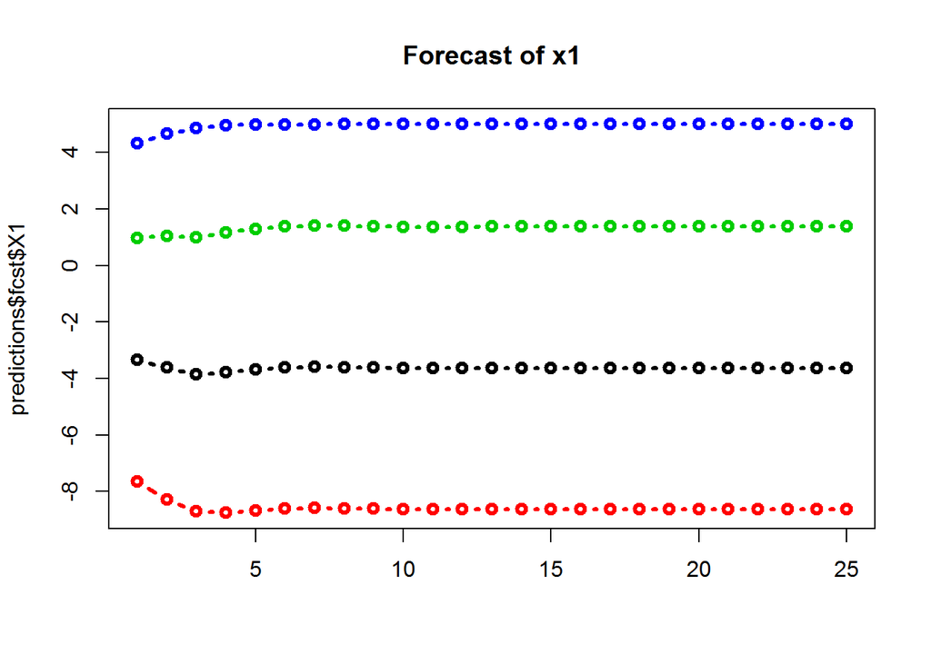

```r
predictions <- predict ( varsimest , n.ahead = 25 ,ci = 0.95)
matplot(predictions$fcst$X1,type = "b",pch = 21,lty = 1,lwd = 3,main = "Forecast of x1")
```

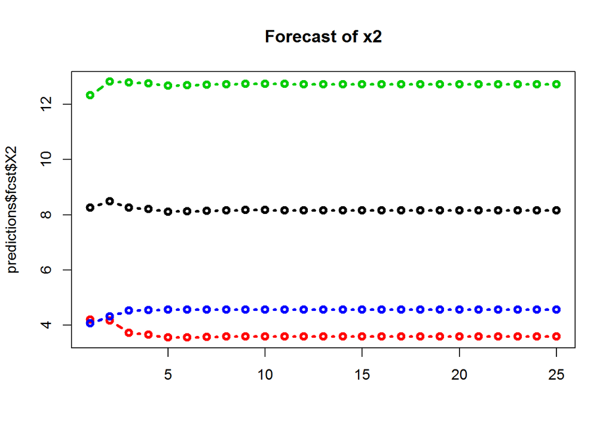

```r
matplot(predictions$fcst$X2,type = "b",pch = 21,lty = 1,lwd = 3,main = "Forecast of x2")
```

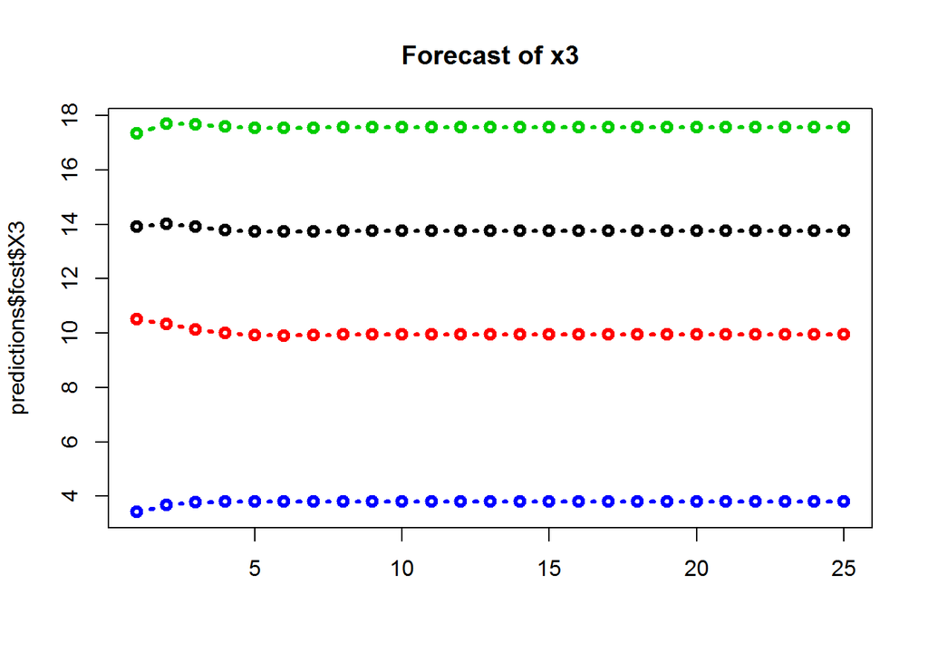

```r
matplot(predictions$fcst$X3,type = "b",pch = 21,lty = 1,lwd = 3,main = "Forecast of x3")
```

Посмотрим на многомерную VAR модель минутных цен фьючерсов Si-12.16,Brent-11.16,RTS-12.16 за 10.10.2016 года

```r
moex <- read.csv("./moex.csv",sep = ";")
head(moex)
```

```
##    X.TIME.    Si brent   rts
## 1 10:01:00 63268 51.57 99650
## 2 10:02:00 63247 51.61 99670
## 3 10:03:00 63238 51.66 99750
## 4 10:04:00 63262 51.65 99710
## 5 10:05:00 63249 51.66 99800
## 6 10:06:00 63297 51.66 99680
```

```r
n <- dim(moex)[1]
prices <- as.matrix(moex[,2:4])
mean(prices)
```

```
## [1] 54651.3
```

Для просмотра на цен графике стандартизуем цены
$$standard prices = (prices- mean(prices))/ \sqrt{var(prices)}$$

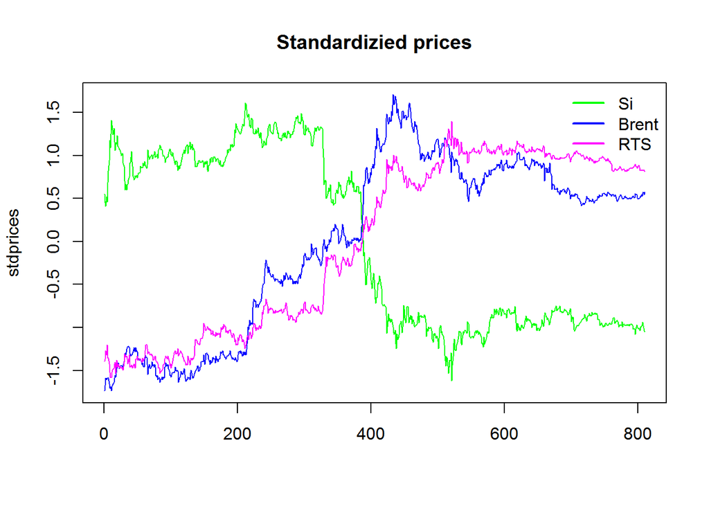

```r
stdprices <- prices

stdprices[,1] <- (prices[,1] - mean(prices[,1]))/sqrt(var(prices[,1]))
stdprices[,2] <- (prices[,2] - mean(prices[,2]))/sqrt(var(prices[,2]))
stdprices[,3] <- (prices[,3] - mean(prices[,3]))/sqrt(var(prices[,3]))
matplot(stdprices,type ="l",main = "Standardizied prices",lty = 1,col = c("green","blue","magenta"))
legend("topright",c("Si","Brent","RTS"),bty="n",lwd = 2,col = c("green","blue","magenta"))
```

От цен перейдем к доходностям

```r
rates <- prices[2:n,]/prices[1:{n-1},]-1
head(rates)
```

```
##                 Si         brent           rts
## [1,] -0.0003319214  0.0007756448  0.0002007025
## [2,] -0.0001422992  0.0009688045  0.0008026487
## [3,]  0.0003795186 -0.0001935734 -0.0004010025
## [4,] -0.0002054946  0.0001936108  0.0009026176
## [5,]  0.0007589053  0.0000000000 -0.0012024048
## [6,]  0.0004423590  0.0000000000  0.0000000000
```

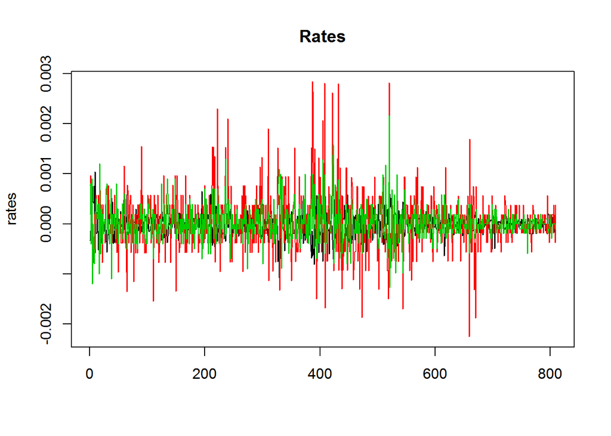

```r
matplot(rates,type= "l",lty = 1, main= "Rates")
```

## 0.3 Кросс-ковариационная, кросс-корреляционная функция

Пусть $x_{t},y_{t},t=0,±1,±2,...,$ - стационаpные случайные пpоцессы в шиpоком смысле, т.е.
$$Ex_{t}=μ_{x},Ey_{t}=μ_{y}$$
$$Dx_{t}=σ_{x}²,Dy_{t}=σ_{y}²$$
$$c_{x}(t,t+m)=E(x_{t}-μ_{x})(x_{t+m}-μ_{x})=c_{x}(m)$$
$$c_{y}(t,t+m)=E(y_{t}-μ_{y})(y_{t+m}-μ_{y})=c_{y}(m)$$
Кpосс-коваpиационная функция процессов $x_{t},y_{t}$ опpеделяется фоpмулой
$$c_{xy}(s,t)=E(x_{s}-μ_{x})(y_{t}-μ_{y}); s,t=0,±1,±2,...$$
Cтационаpные случайные пpоцессы и называются совместно стационаpными в шиpоком смысле, если
$$c_{xy}(t,t+m)=E(x_{t}-μ_{x})(y_{t+m}-μ_{y})=c_{xy}(m); m=0,±1,±2,...$$

Кpосс-коваpиационная функция паpы пpоцессов выpажает меpу линейной зависимости значений $x_{t+m}и y_{t}$. Следует заметить, что кpосс-коваpиационная функция, вообще говоpя, не является симметpичной функцией аpгумента m. Веpно следующее соотношение
$$c_{xy}(m)=c_{yx}(-m)$$
Наиболее частое использование кpосс-коваpиационной функции иллюстpиpуется следующим пpимеpом. Пусть пpоцессы и связаны соотношением $y_{t}=Ax_{t-d}$ где $d$ - целое число. Говоpят, что $x_{t}$ опеpежает $y_{t }$ на $d$ шагов, если $d > 0$, и отстает от $y_{t }$ на $d$ шагов, если $d < 0$. Пpедположим для пpостоты, что $Ex_{t}=0,Ey_{t}=0$. Тогда кpосс-коваpиационная функция паpы пpоцессов $x_{t}$ и $y_{t}$ pавна
$$c_{xy}(m)=Ex_{t+m}y_{t}=AEx_{t+m}x_{t-d}=Ac_{x}(m+d)$$

автоковаpиационной функции пpоцесса $x_{t}$, умноженной на $А$ и сдвинутой на $|d|$ вpеменных лагов впpаво, если $x_{t}$ опеpежает $y_{t}$ на $d$ шагов $(d > 0)$, или влево, если $x_{t}$ отстает от на $d$ шагов.

Продемонстрируем это свойство автокорреляции на процессе авторегрессии первого порядка

```r
library(fArma)
```

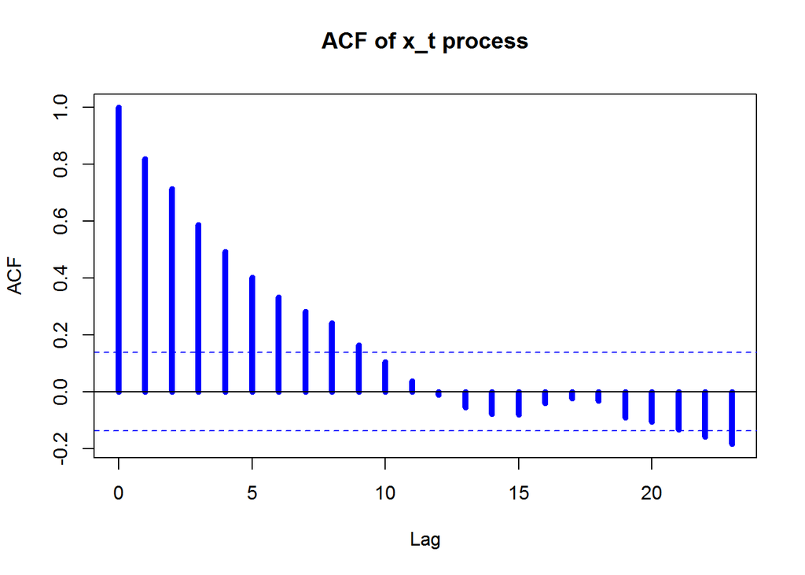

```r
fi <- 0.9
sigma <- 2
model <- list(ar = fi)
x <- arima.sim(model=model,n = 200,innov=rnorm(200,0,sd=sigma))
acf(x,main = "ACF of x_t process",lwd = 5,col = "blue")
```

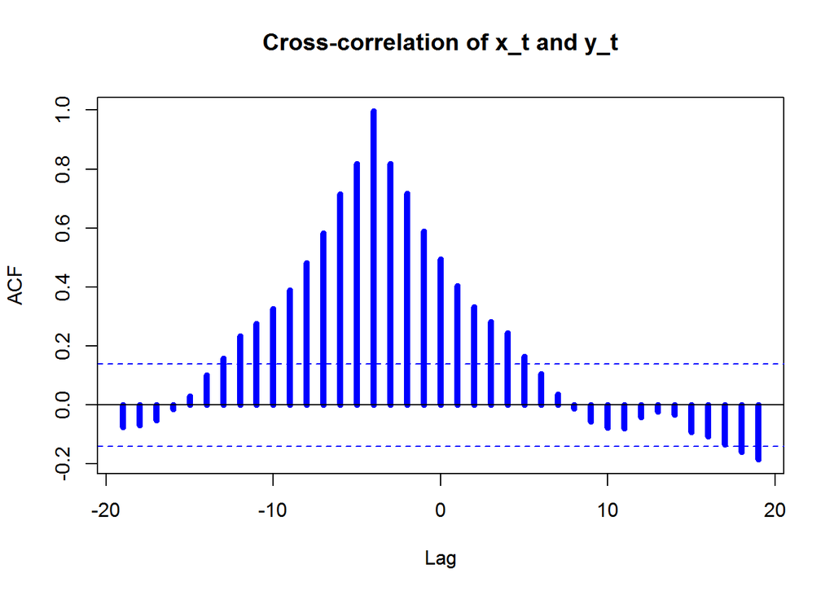

```r
d <- 5
y <- x[d:200]
ccf(y,x[1:{200-d+1}],lwd = 5, main = "Cross-correlation of x_t and y_t",col = "blue")
```

В статистических исследованиях выводы о запаздывании одного пpоцесса относительно дpугого делаются на основе выбоpочной кpосс-коваpиационной функции. Кpосс-коppеляционная функция паpы процессов $x_{t}$ и $y_{t}$, опpеделяется фоpмулой
$$ρ_{xy}(m)=((с_{xy}(m))/(√(c_{x}(0),c_{y}(0))))$$
Посмотрим на кросс-корреляции доходностей

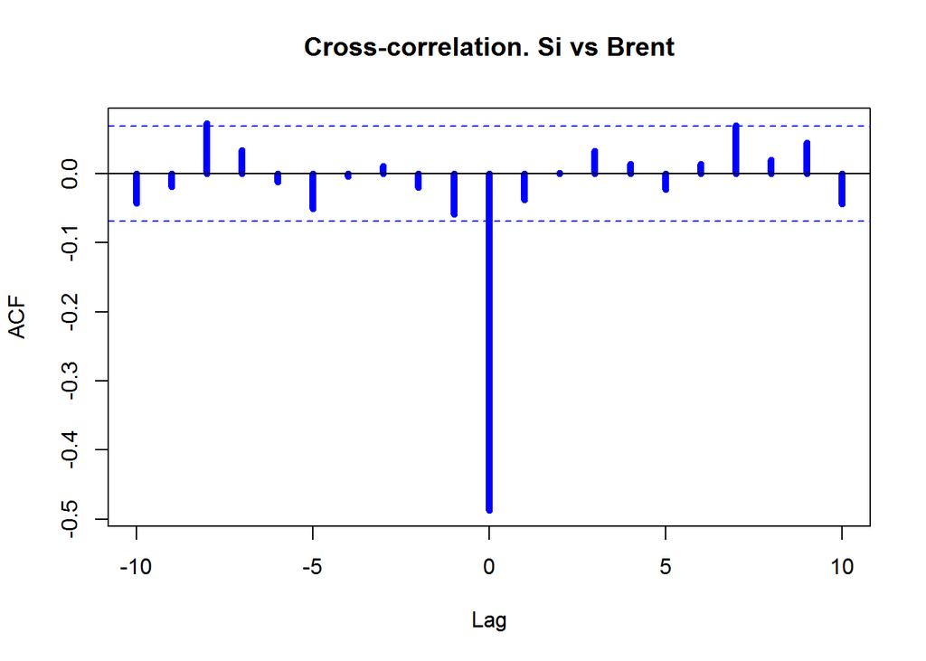

```r
ccf(rates[,1],rates[,2],lag.max= 10,type ="correlation", main = "Cross-correlation. Si vs Brent", lwd = 5, col = "blue")
```

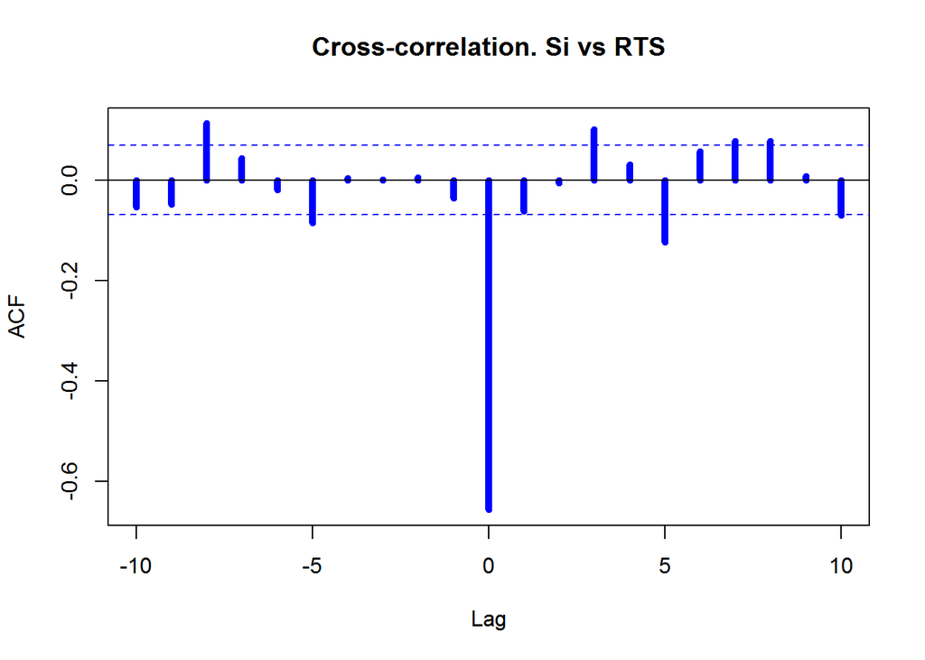

```r
ccf(rates[,1],rates[,3],lag.max= 10,type = "correlation", main ="Cross-correlation. Si vs RTS", lwd = 5, col = "blue")
```

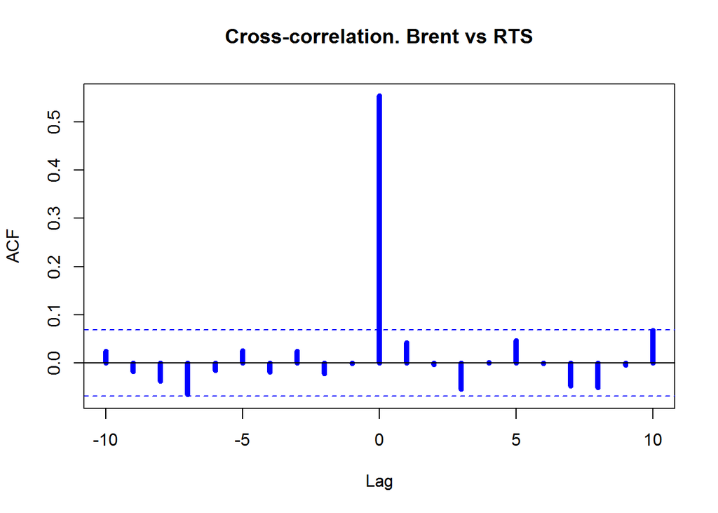

```r
ccf(rates[,2],rates[,3],lag.max= 10,type = "correlation", main ="Cross-correlation. Brent vs RTS", lwd = 5, col = "blue")
```

Прошли те золотые годы, когда быстрой связи и компьютеров не было и торги проходили с голоса. Сейчас же опережения одного актива другим на минутных данных нет. Хотя в данном случае раньше в динамике котировок задержка была. Она и сейчас есть только исчисляется микросекундами. Оценим порядок 3-х мерной модели авторегресии

```r
order <- VARselect(rates, lag.max = 5, type="none")
order
```

```
## $selection
## AIC(n)  HQ(n)  SC(n) FPE(n)
##      1      1      1      1
##
## $criteria
##                    1             2             3             4
## AIC(n) -4.882135e+01 -4.880932e+01 -4.880871e+01 -4.879994e+01
## HQ(n)  -4.880119e+01 -4.876900e+01 -4.874823e+01 -4.871929e+01
## SC(n)  -4.876885e+01 -4.870433e+01 -4.865123e+01 -4.858996e+01
## FPE(n)  6.268405e-22  6.344247e-22  6.348147e-22  6.404103e-22
##                    5
## AIC(n) -4.879823e+01
## HQ(n)  -4.869742e+01
## SC(n)  -4.853575e+01
## FPE(n)  6.415127e-22
```

Оценим VAR(1) модель.

```r
varrates <-   VAR(rates, p = 1 ,season = NULL, exogen = NULL)
summary(varrates)
```

```
##
## VAR Estimation Results:
## =========================
## Endogenous variables: Si, brent, rts
## Deterministic variables: const
## Sample size: 808
## Log Likelihood: 16279.811
## Roots of the characteristic polynomial:
## 0.1713 0.1013 0.03537
## Call:
## VAR(y = rates, p = 1, exogen = NULL)
##
##
## Estimation results for equation Si:
## ===================================
## Si = Si.l1 + brent.l1 + rts.l1 + const
##
##            Estimate Std. Error t value Pr(>|t|)
## Si.l1    -3.460e-02  4.749e-02  -0.729    0.466
## brent.l1 -4.145e-03  1.535e-02  -0.270    0.787
## rts.l1   -4.683e-02  3.001e-02  -1.561    0.119
## const    -5.233e-06  7.325e-06  -0.714    0.475
##
##
## Residual standard error: 0.0002077 on 804 degrees of freedom
## Multiple R-Squared: 0.004471,    Adjusted R-squared: 0.0007567
## F-statistic: 1.204 on 3 and 804 DF,  p-value: 0.3074
##
##
## Estimation results for equation brent:
## ======================================
## brent = Si.l1 + brent.l1 + rts.l1 + const
##
##            Estimate Std. Error t value Pr(>|t|)
## Si.l1    -2.092e-01  1.330e-01  -1.573   0.1161
## brent.l1 -9.094e-02  4.300e-02  -2.115   0.0347 *
## rts.l1    7.354e-02  8.402e-02   0.875   0.3817
## const     3.316e-05  2.051e-05   1.616   0.1064
## ---
## Signif. codes:  0 '***' 0.001 '**' 0.01 '*' 0.05 '.' 0.1 ' ' 1
```

[output cut: 22 more lines]

```
## F-statistic: 2.155 on 3 and 804 DF,  p-value: 0.09195
##
##
##
## Covariance matrix of residuals:
##               Si      brent        rts
## Si     4.314e-08 -5.905e-08 -4.758e-08
## brent -5.905e-08  3.383e-07  1.118e-07
## rts   -4.758e-08  1.118e-07  1.188e-07
##
## Correlation matrix of residuals:
##            Si   brent     rts
## Si     1.0000 -0.4888 -0.6645
## brent -0.4888  1.0000  0.5574
## rts   -0.6645  0.5574  1.0000
```